# Project5

```
##    Min. 1st Qu.  Median    Mean 3rd Qu.    Max.
##    1.00    7.00   14.00   15.87   21.00   72.00
```

In the line below I see that 546 wines are greater than 50ppm so they have SO2 and 1053 wines don’t have SO2.

```
## [1] 546  12
```

```
## [1] 1053   12
```

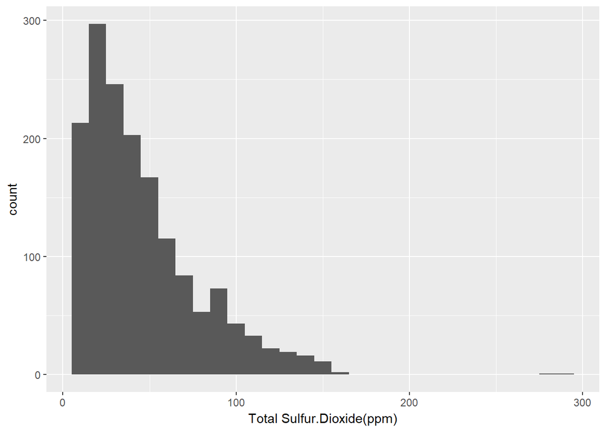

After looking Total.Sulur.Dioxide i start wondering how that affect the overall quality of the wine.So i decide to facet_wrap that to my code. Which you can see below.

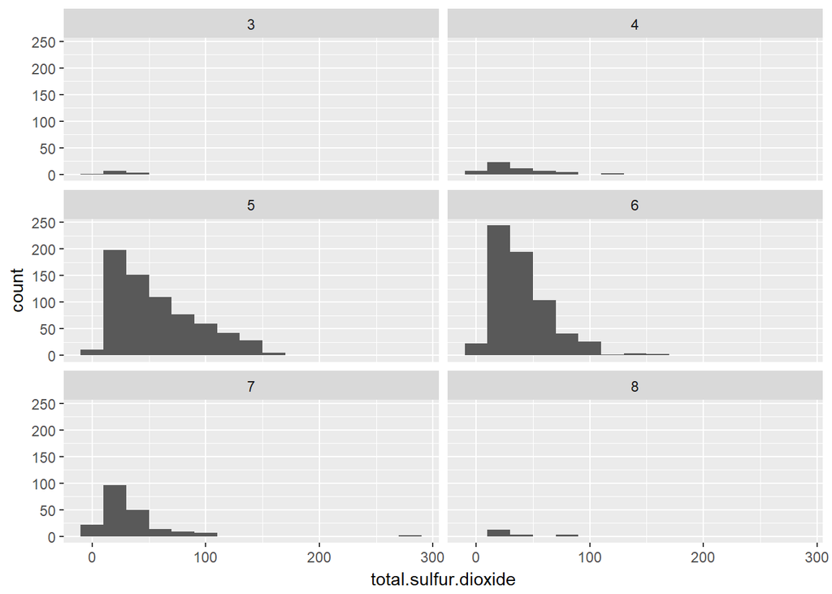

From the data above i notice that most Total.SUlfur.Dioxide have a quality of 5 or a 6.

The information below show Min,1st Qu,Median,Mean, 3rd Qu, and Max for each quality type

```
## redwine$quality: 3
##    Min. 1st Qu.  Median    Mean 3rd Qu.    Max.
##     9.0    12.5    15.0    24.9    42.5    49.0
## --------------------------------------------------------
## redwine$quality: 4
##    Min. 1st Qu.  Median    Mean 3rd Qu.    Max.
##    7.00   14.00   26.00   36.25   49.00  119.00
## --------------------------------------------------------
## redwine$quality: 5
##    Min. 1st Qu.  Median    Mean 3rd Qu.    Max.
##    6.00   26.00   47.00   56.51   84.00  155.00
## --------------------------------------------------------
## redwine$quality: 6
##    Min. 1st Qu.  Median    Mean 3rd Qu.    Max.
##    6.00   23.00   35.00   40.87   54.00  165.00
## --------------------------------------------------------
## redwine$quality: 7
##    Min. 1st Qu.  Median    Mean 3rd Qu.    Max.
##    7.00   17.50   27.00   35.02   43.00  289.00
## --------------------------------------------------------
## redwine$quality: 8
##    Min. 1st Qu.  Median    Mean 3rd Qu.    Max.
##   12.00   16.00   21.50   33.44   43.00   88.00
```

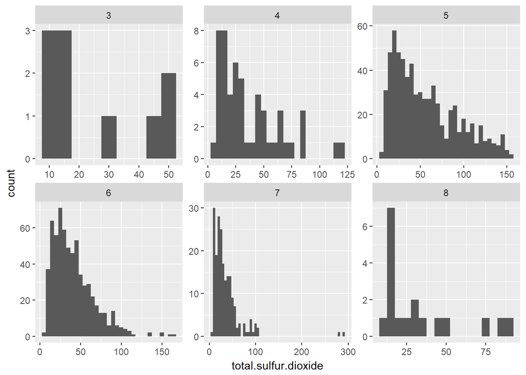

The graph above is facet_wrap with a free scale giving me a better idea of toal.sulfur.dioxide for each quality.Quality 5 and 6 a range from close to 0 to 150. While Quality 3, 4, and 8 have more a spread out Total.Sulfur.Dioxide

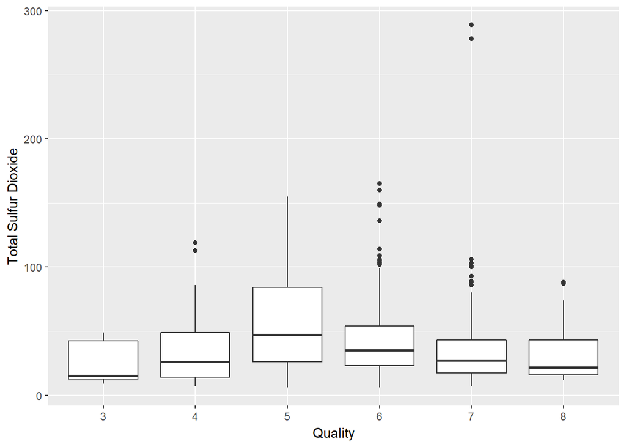

# Univeriate Analysis:

### Structure of the Dataset:

Variables :11 Obj:1599

Fixed.acidity ,Volatile.acidity,citric.acid.,residual.sugar,chlorides, free.sulfur.dioxide,total.sulfur.dioxide.,density,pH,sulphates,alcohol,

Quality : Ranking 0 -10 (Worst to best)

Observation: The mean of th quality is around 5.6.

Most wine have a quality of a 5 or a 6.

Most wine use less residual.sugar(less than 2.5)

Most have less than 100ppm (fix.acidty)the quality of wine is a 6

### What is the most interesting from the dataset?

Something that i notice in most of the data set of the wine have use less element what i mean that elements like fixed.acidity , volatile.acidity, residual.sugar,chlorides,freesulfur.dioxide,toal.sulfur.dioxide,sulphates,and alcohol start with small quantity of the element but have a huge count and more the quantity of the element the less is the count. We can determin that each element affect the quality of the wine by have different reaction with each other if not having specific amount.

### What is something strange i see in the database?

One strange thing i saw was citric.acid because when have close to 0 citric.acid it have high level count but then it slowly start to drop then near .18 citic.acid jump in count and then slowly start to decrease. I believe their must be a element that citric acid reaction we if the quantity is measure correctly. I use the correlation diagram to see which element have a strong relationship.

### What can help specify my theory?

Well i look at the total.sulfur.dioxide and quality above and see that their is some kind relation with elements and quality if you look at the scale most total.sulfur.dioxide have less than 100 ppm very few have anything getter than than amount. I want to look at the two element and how they affect each other relationship that have a positive correlation and a negative correlation.

# Correlation

After looking into the relationship between quality and Total.Sulfur.Dioxide I start wondering about what other elements have a correlation with each other.I created two corrplot to give me a better idea of correlation between the element. The reason i create two plot was that first plot with square gave me a good idea how each correleation between each element but it still didn’t tell me how close to -1 or 1 so i plot another so i can get those results.

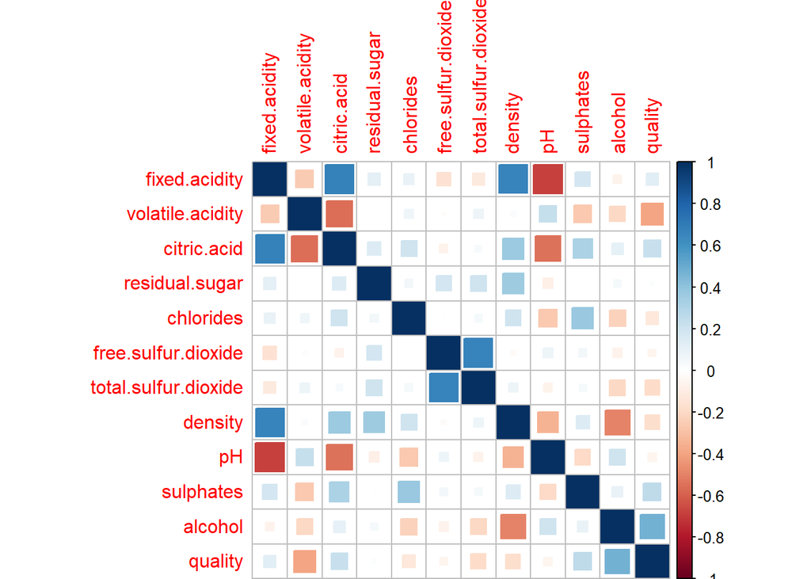

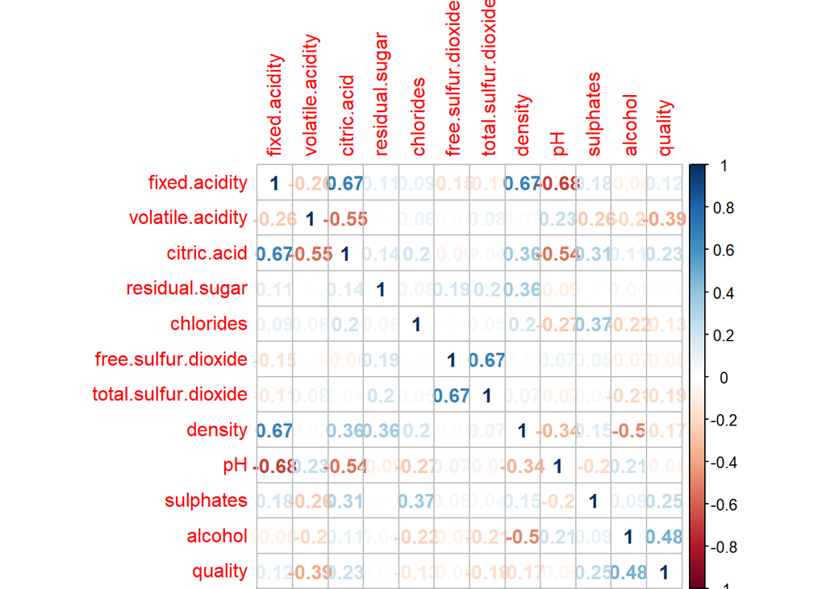

# Bivariate:

### Fix.acidity and Citric.Acid

After looking at the corr.plot from above i notice that fixed.acidity which is the acid involved in wine and citric.acid which is add freshness and flavour have a correlation of .67.I want to see more about the relationship so i decide to create a scatter plot

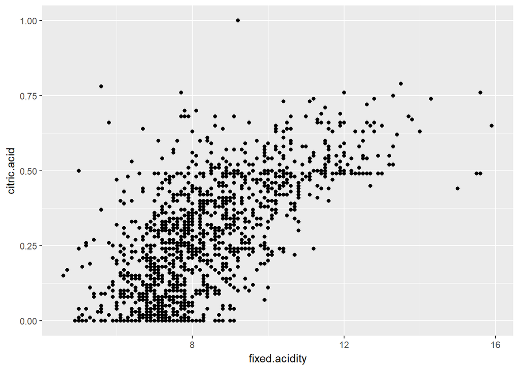

The first think i know notice that their alot of overplotting between fixed.acidiy = 6 and 10. I’m going to use aplha to clean up the overplotting.

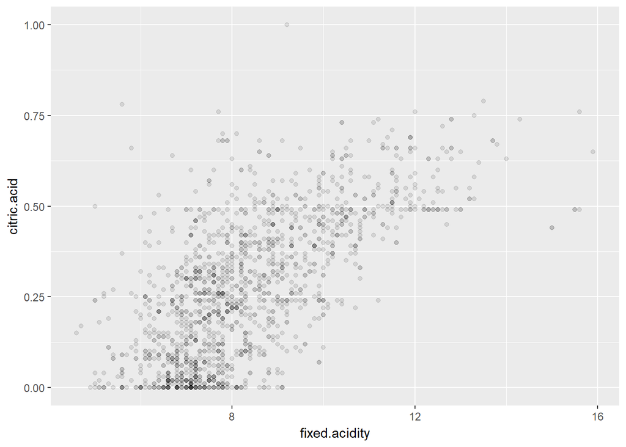

I Clean the overploting the first thing i notice is that most of the citric.acid and fixed.acidity is close to when fixed.acidity is close to 7 and citric.acid is at 0,

```
##
##  Pearson's product-moment correlation
##
## data:  redwine$citric.acid and redwine$fixed.acidity
## t = 36.234, df = 1597, p-value < 2.2e-16
## alternative hypothesis: true correlation is not equal to 0
## 95 percent confidence interval:
##  0.6438839 0.6977493
## sample estimates:
##       cor
## 0.6717034
```

The information from above is the correlation between citric.acid and fixed.acidity using the Peason method.

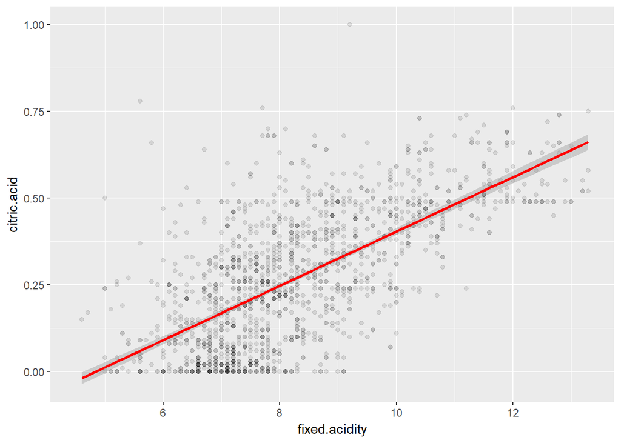

```
##  99%
## 13.3
```

In the graph above i want to see the 99 percent tile so i can have a better idea of the graph without the outliers. The last fixed acidity that is in the 99% is 13.3 anything beyond that is most likely a outlier.

```
## # A tibble: 6 x 6
##   fixed.acidity  mean_acid median_acid max_acid min_acid     n
##           <dbl>      <dbl>       <dbl>    <dbl>    <dbl> <int>
## 1           4.6 0.15000000        0.15     0.15     0.15     1
## 2           4.7 0.17000000        0.17     0.17     0.17     1
## 3           4.9 0.00000000        0.00     0.00     0.00     1
## 4           5.0 0.17166667        0.14     0.50     0.00     6
## 5           5.1 0.05000000        0.01     0.18     0.00     4
## 6           5.2 0.09166667        0.02     0.26     0.00     6
```

The table above is a group_by fixed.acity and citric.acid.I wanted to get the mean ,median,max, min and total of the citric acid when fixed.acidity is at a a specific point.

### Fixed.Acidity and Density

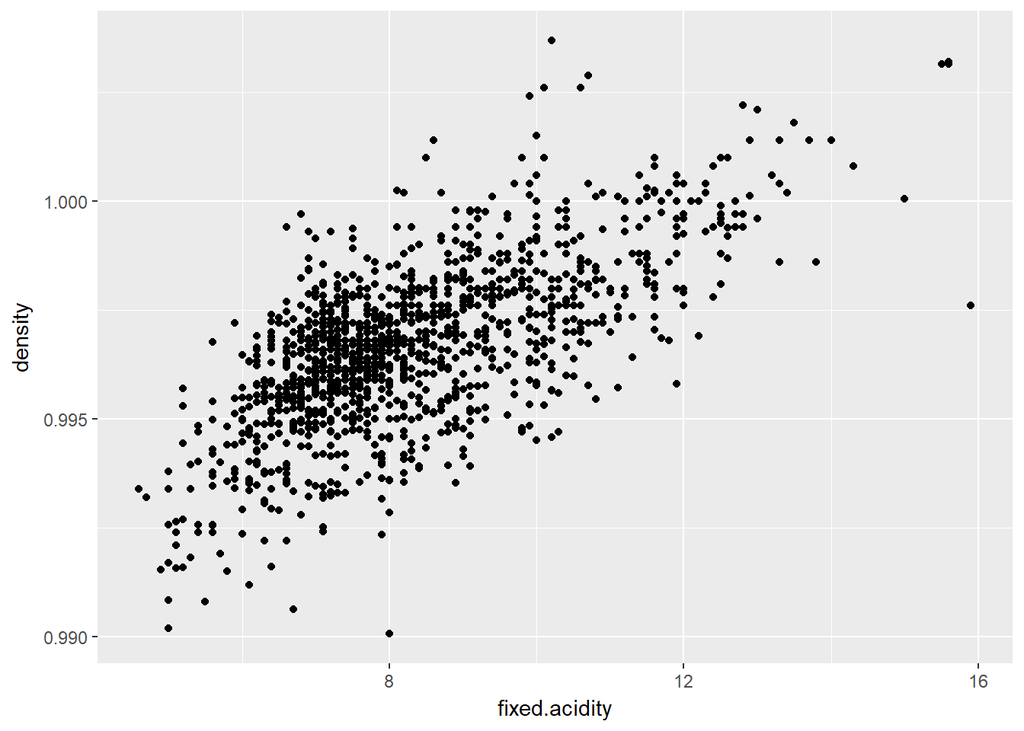

In the graph above I’m plotting between fixed.acidity and density. The problem with this is that there is overploating when fixed.acidity reaches 8. I’m going to need to clean that before going any futher.

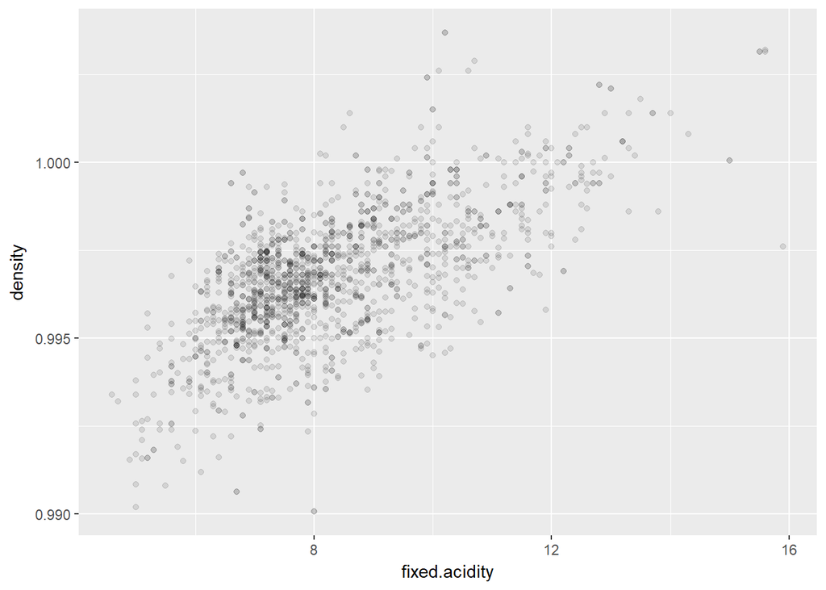

I clean the graph from above you know that most of the plot are around fixed.acidity is around 8 and the density is around.9975.Now I’m wondering how the quality is affect.

```
##
##  Pearson's product-moment correlation
##
## data:  redwine$density and redwine$fixed.acidity
## t = 35.877, df = 1597, p-value < 2.2e-16
## alternative hypothesis: true correlation is not equal to 0
## 95 percent confidence interval:
##  0.6399847 0.6943302
## sample estimates:
##       cor
## 0.6680473
```

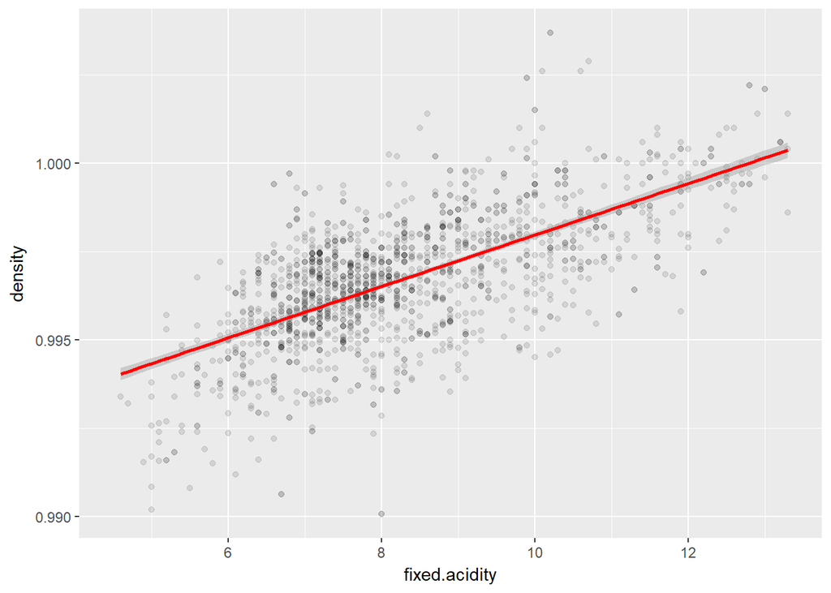

### Fixed.Acidity and pH

After doing the correlation for citric.acid and density seeing that have a positive I want to compare it to element that have a negative correlation.I want to look at pH and fixed.acidity since i know that they have a negative correlation.pH is the acid the wine is.

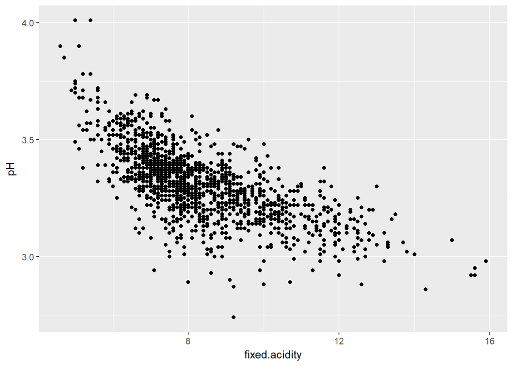

I create a scatter plot the first thing i notice is their alot overplotting around 7 and 8. It better to clean the data so we can have a better understanding of the graph.

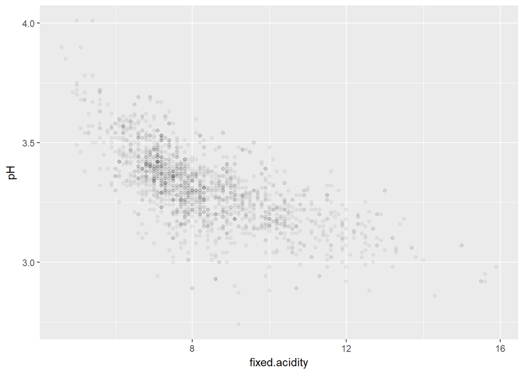

Now that he graph is clean you notice that most of the point are around 7 for fixed.acidity it seem that he relationship stay mostly in that area.

```
##
##  Pearson's product-moment correlation
##
## data:  redwine$pH and redwine$fixed.acidity
## t = -37.366, df = 1597, p-value < 2.2e-16
## alternative hypothesis: true correlation is not equal to 0
## 95 percent confidence interval:
##  -0.7082857 -0.6559174
## sample estimates:
##        cor
## -0.6829782
```

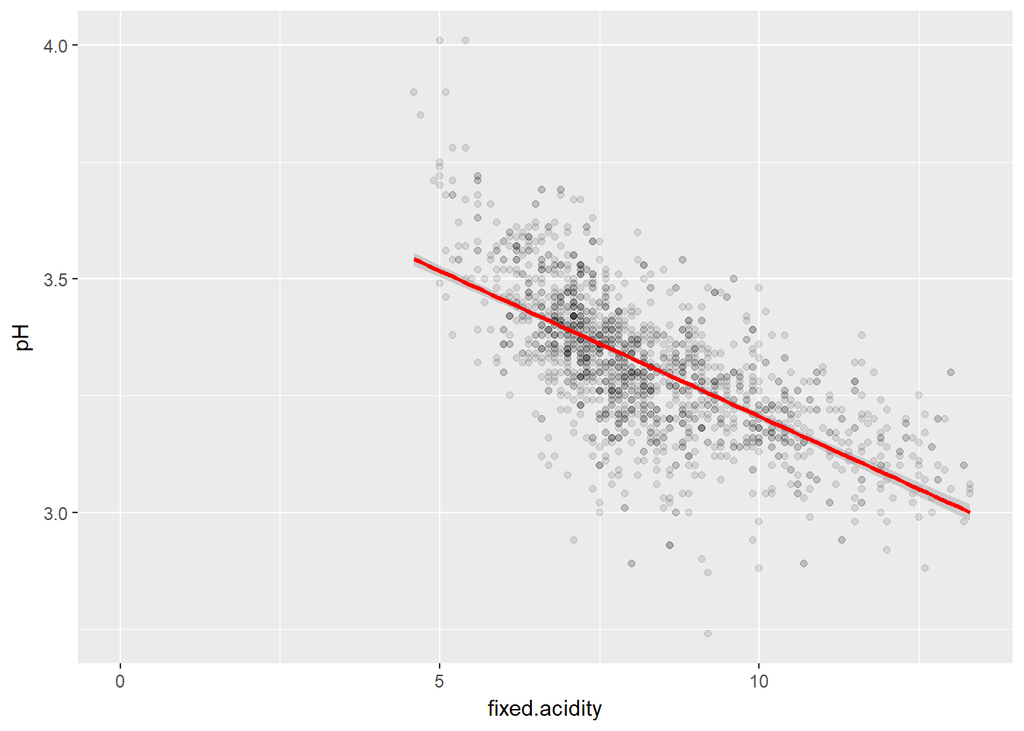

# Bivariate Analysis:

### What are the interesting relationship did you see ?

Their alot of overplotting closer to the center of the graph (Fixed.Acidity/ Density and Fixed.Acidity/pH) .Fix.acidity and citric.acid is different because most of the overplotting was found when citric acid is 0. This could mean that fixed.acidity could have a strong relationship with citric.acid when it at 0.

### Strongest Relationship found?

According to correlation diagram fixed.acidity have a strong relation with both citric.acid and denstiy at .67. When i look at fixed.acidity and density scatter plot graph it look like it have strong reaching since more of the scatter plot overplotting each other but still have a few that are spread out.Also fixed.acidity have a negative relation with pH when you look at the graph you can tell since it going in a negative linear line.

# Multivariate:

### Fixed.Acidity and Citric.acid with quality

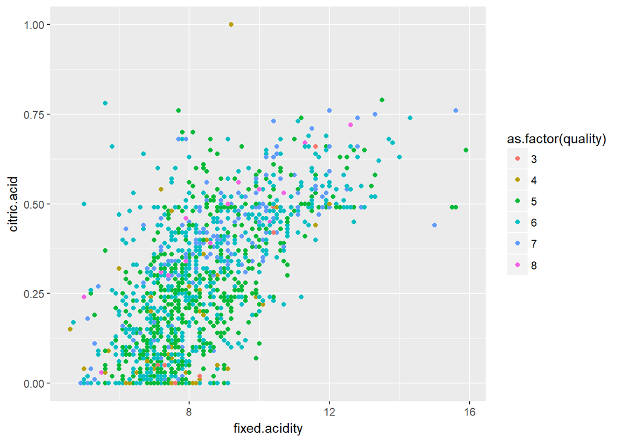

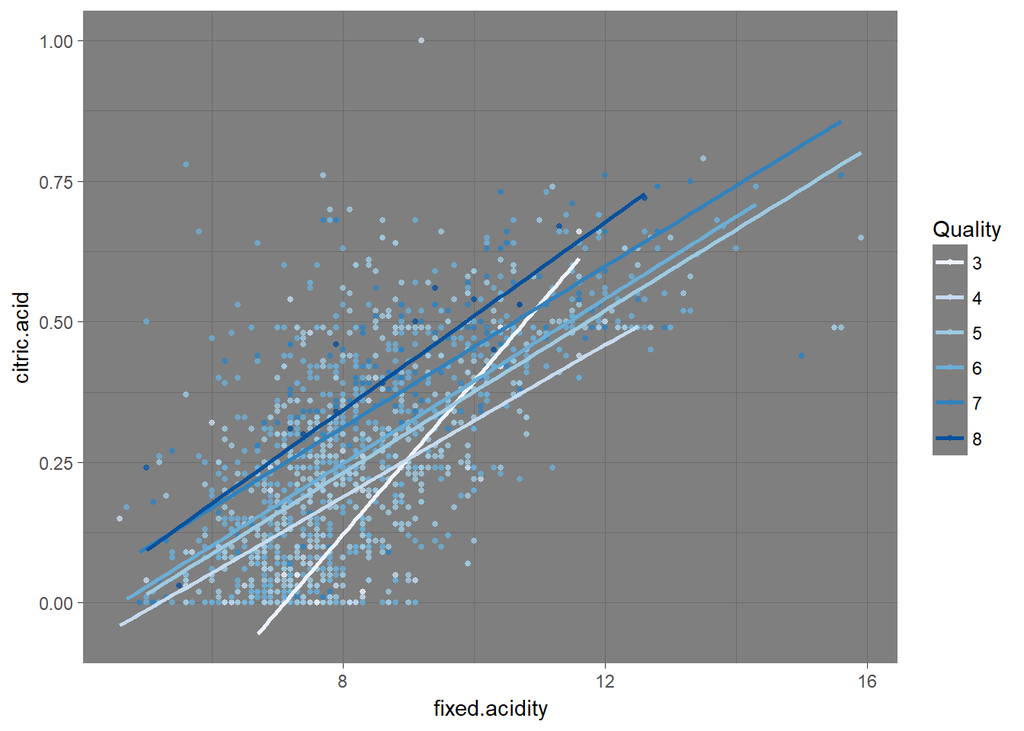

In the graph above i wanted to see the quality of the citric.acid and fixed.acidity the lighter the color the worst is the quality , the darker the color the better the quality.SOmething i notice from this graph is that most of the 3 and 4 quality are below .25 ctiric acid and most 7 and 8 quality are above .25 citric with 8 fixed.acidity

The information below we can see how many of each type of quality is there between 0 - 10.

```
##    Min. 1st Qu.  Median    Mean 3rd Qu.    Max.
##   3.000   5.000   6.000   5.636   6.000   8.000
```

```
## quality
##   3   4   5   6   7   8
##  10  53 681 638 199  18
```

In the infromation above i break down the quality to see how many are in each quality type. 0,1,2,9,10 are not show because their no value in the data.

## Fixed.Acidity and Density with quality

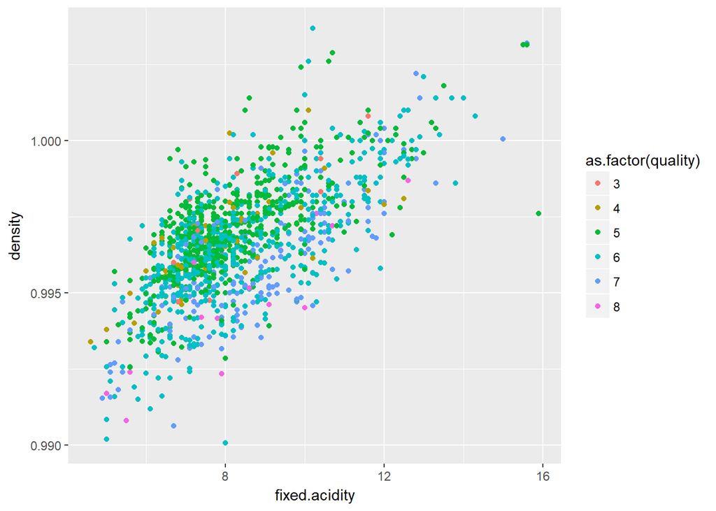

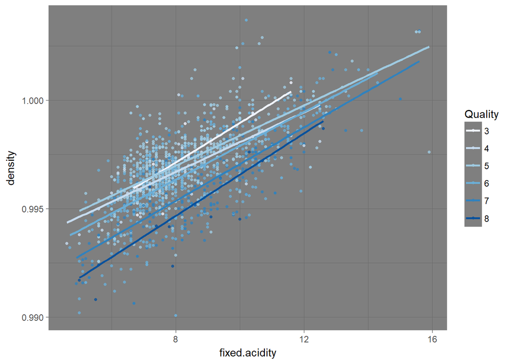

The graph above now show me the quality of the density and fixed.acity.Something I notice from the graph above is that closer you get to .995 from 1 in density the better quality get and most of them are between 6 and 8 fixed,acidity

## Fixed.Acidity and pH with quality

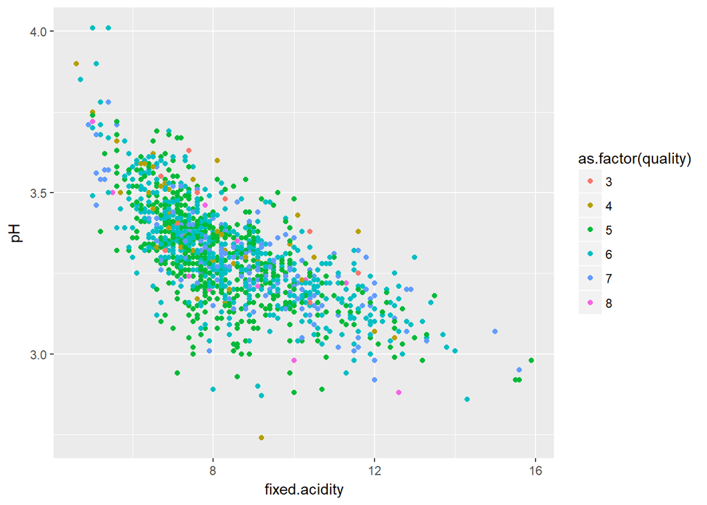

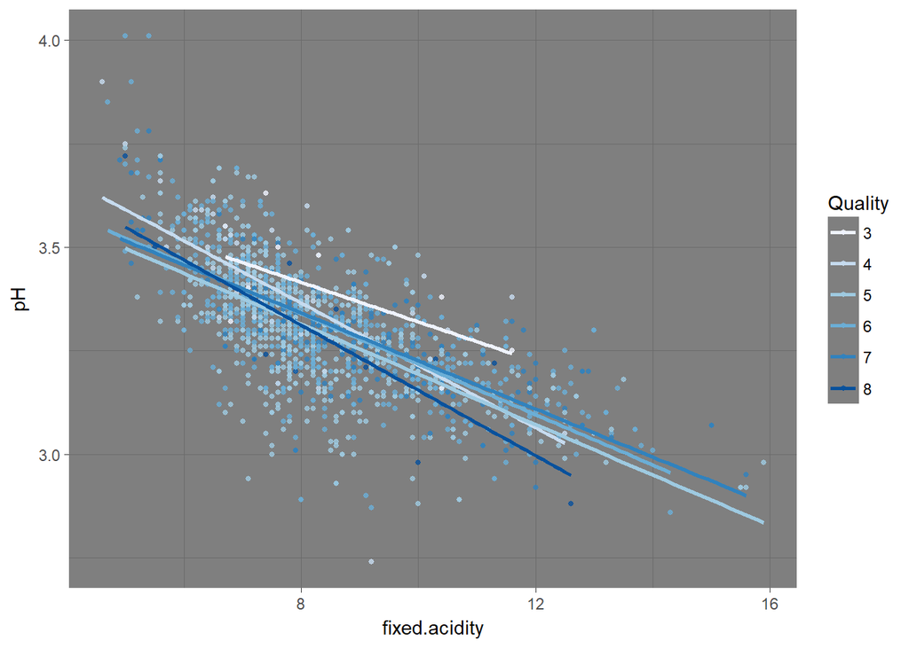

# Multivariate Analysis:

### What are the interesting relationship did you see ?

Something that I notice between all three graph is that one point in each graph they have a intercept or come close to intercept with each other.Two of the graph have positive linear slope but that can be due to a postive correlation that they have with each other. Something i was suprise to see that all three have overplotting instead a spread out relationship.

### Strongest Relationship found?

It between fixed.acidity with citric.acid or with Density since their correlation were the same. Since we add quality to the mix it just let us know when does the quality of the wine are plotted between fixed.acidity with citric.acid or density.

# Three Interesting Graph

Will working on the project I found these Three graph to be the most interesting

## Graph 1:

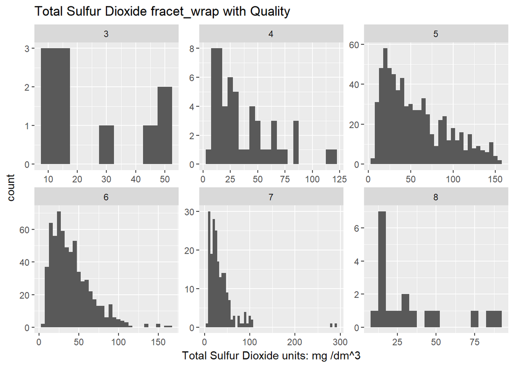

The reason i beleive this graph is import is because it show me it break down how total.sulfur.dioxide with the quality of the wine. When the quality is 3 most of the wine is less than 50ppm meaning now there no S02 in the wine. When you get quality of the wine is 5 you that reach it peak near 25 but the tail slowly start dropping this can mean that SO2 have a higher detection.Lastly I notice that their are no wine rating of 0,1,2,9,10.

## Graph 2:

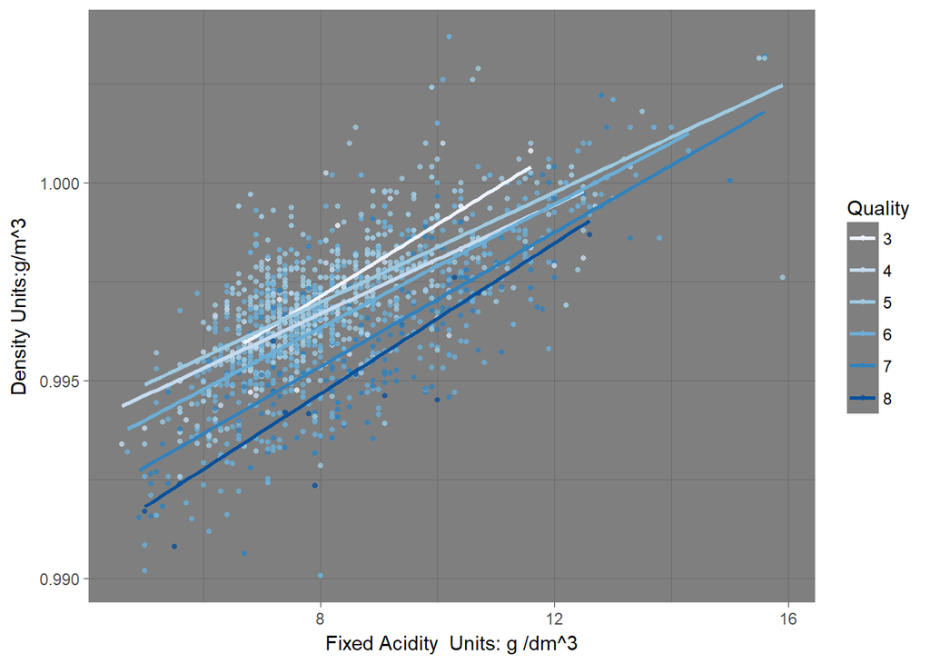

In the graph above is important because it show how the density and Fixed Acidity afffect the quality of the wine. Somthing I notice is when the Fixed Acidity is between 13g/dm^3 and 14g/dm^3 the quality of the wine start to get to each other. If the sample was larger we could determine if it ever intercept with each other. Another is the most the better quality wine is when the density is .992g/m^3 and the worst is closer to .997 g/m^3.

## Graph 3

[figure not shown]

# Limitation:

A couple of limitation for was understanding the each element and seeing how they affect the wine or each element. Luckly i saw that the file come with a explanation of each element but don’t really give me a idea how each element with each other. So i start with Total.Sulfur.Dioxide i know that it can affect the quality of the wine if the ppm is to high. I wanted to have a better idea how each element relate to each other i decide to create 2 correlation graph to have abetter idea.

# Ideas:

I had a couple ideas while working with these set of data. The first was data could contain infomation how well each wine sold and then compare it to the quality of the wine and each element. The problem with this method is that maybe some wine are the same but sold at a different cost at different stores. Another is to see how Temperature affect the element and the overal quality of the wine. The problem is that i see that all the wine must have the same amount of time in that temperature it would be hard to tell because they might have diferent makers.

# Conclusion:

This project help me understand the use of R and graph for data science.Graph are really important to this field because it help the reader have a better picture when you explain the research you have done.